# Case Study 1

Liang Huang and James Clay

October 16, 2018

## This report represents the findings pertaining to various beers and breweries in the states.

Breweries per State

| State | Number of Breweries |
| --- | --- |
| AK | 7 |
| AL | 3 |
| AR | 2 |
| AZ | 11 |
| CA | 39 |
| CO | 47 |
| CT | 8 |
| DC | 1 |
| DE | 2 |
| FL | 15 |
| GA | 7 |
| HI | 4 |
| IA | 5 |
| ID | 5 |
| IL | 18 |
| IN | 22 |
| KS | 3 |
| KY | 4 |
| LA | 5 |
| MA | 23 |
| MD | 7 |
| ME | 9 |
| MI | 32 |
| MN | 12 |
| MO | 9 |
| MS | 2 |
| MT | 9 |
| NC | 19 |
| ND | 1 |
| NE | 5 |
| NH | 3 |
| NJ | 3 |
| NM | 4 |
| NV | 2 |
| NY | 16 |
| OH | 15 |
| OK | 6 |
| OR | 29 |
| PA | 25 |
| RI | 5 |
| SC | 4 |
| SD | 1 |
| TN | 3 |
| TX | 28 |
| UT | 4 |
| VA | 16 |
| VT | 10 |
| WA | 23 |
| WI | 20 |
| WV | 1 |
| WY | 4 |

## Data from various agencies was combined to produce one complete set containing all variables pertaining to breweries and beers in the states. The below table represents the first and last rows, indicating a successful merge.

First Rows

| Brew_ID | Beer_name | Beer_ID | ABV | IBU | Style | Ounces | Name | City | State |
| --- | --- | --- | --- | --- | --- | --- | --- | --- | --- |
| 1 | Get Together | 2692 | 0.045 | 50 | American IPA | 16 | NorthGate Brewing | Minneapolis | MN |
| 1 | Maggie’s Leap | 2691 | 0.049 | 26 | Milk / Sweet Stout | 16 | NorthGate Brewing | Minneapolis | MN |
| 1 | Wall’s End | 2690 | 0.048 | 19 | English Brown Ale | 16 | NorthGate Brewing | Minneapolis | MN |
| 1 | Pumpion | 2689 | 0.060 | 38 | Pumpkin Ale | 16 | NorthGate Brewing | Minneapolis | MN |
| 1 | Stronghold | 2688 | 0.060 | 25 | American Porter | 16 | NorthGate Brewing | Minneapolis | MN |
| 1 | Parapet ESB | 2687 | 0.056 | 47 | Extra Special / Strong Bitter (ESB) | 16 | NorthGate Brewing | Minneapolis | MN |

Last Rows

|  | Brew_ID | Beer_name | Beer_ID | ABV | IBU | Style | Ounces | Name | City | State |
| --- | --- | --- | --- | --- | --- | --- | --- | --- | --- | --- |
| 2405 | 556 | Pilsner Ukiah | 98 | 0.055 | NA | German Pilsener | 12 | Ukiah Brewing Company | Ukiah | CA |
| 2406 | 557 | Heinnieweisse Weissebier | 52 | 0.049 | NA | Hefeweizen | 12 | Butternuts Beer and Ale | Garrattsville | NY |
| 2407 | 557 | Snapperhead IPA | 51 | 0.068 | NA | American IPA | 12 | Butternuts Beer and Ale | Garrattsville | NY |
| 2408 | 557 | Moo Thunder Stout | 50 | 0.049 | NA | Milk / Sweet Stout | 12 | Butternuts Beer and Ale | Garrattsville | NY |
| 2409 | 557 | Porkslap Pale Ale | 49 | 0.043 | NA | American Pale Ale (APA) | 12 | Butternuts Beer and Ale | Garrattsville | NY |
| 2410 | 558 | Urban Wilderness Pale Ale | 30 | 0.049 | NA | English Pale Ale | 12 | Sleeping Lady Brewing Company | Anchorage | AK |

## With data of this size, it is inevitable that values were not reported. Below indicates the total number of missing values per variable group.

Missing Values

|  | x |
| --- | --- |
| Brew_ID | 0 |
| Beer_name | 0 |
| Beer_ID | 0 |
| ABV | 62 |
| IBU | 1005 |
| Style | 0 |
| Ounces | 0 |
| Name | 0 |
| City | 0 |
| State | 0 |

## Each state has unique alcohol contents and international bitterness units. The below table shows the median of each value per state.

The Middle Values

| States | Alcohol by Volume | Bitterness |
| --- | --- | --- |
| AK | 0.0560 | 46.0 |
| AL | 0.0600 | 43.0 |
| AR | 0.0520 | 39.0 |
| AZ | 0.0550 | 20.5 |
| CA | 0.0580 | 42.0 |
| CO | 0.0605 | 40.0 |
| CT | 0.0600 | 29.0 |
| DC | 0.0625 | 47.5 |
| DE | 0.0550 | 52.0 |
| FL | 0.0570 | 55.0 |
| GA | 0.0550 | 55.0 |
| HI | 0.0540 | 22.5 |
| IA | 0.0555 | 26.0 |
| ID | 0.0565 | 39.0 |
| IL | 0.0580 | 30.0 |
| IN | 0.0580 | 33.0 |
| KS | 0.0500 | 20.0 |
| KY | 0.0625 | 31.5 |
| LA | 0.0520 | 31.5 |
| MA | 0.0540 | 35.0 |
| MD | 0.0580 | 29.0 |
| ME | 0.0510 | 61.0 |
| MI | 0.0620 | 35.0 |
| MN | 0.0560 | 44.5 |
| MO | 0.0520 | 24.0 |
| MS | 0.0580 | 45.0 |
| MT | 0.0550 | 40.0 |
| NC | 0.0570 | 33.5 |
| ND | 0.0500 | 32.0 |
| NE | 0.0560 | 35.0 |
| NH | 0.0550 | 48.5 |
| NJ | 0.0460 | 34.5 |
| NM | 0.0620 | 51.0 |
| NV | 0.0600 | 41.0 |
| NY | 0.0550 | 47.0 |
| OH | 0.0580 | 40.0 |
| OK | 0.0600 | 35.0 |
| OR | 0.0560 | 40.0 |
| PA | 0.0570 | 30.0 |
| RI | 0.0550 | 24.0 |
| SC | 0.0550 | 30.0 |
| SD | 0.0600 | NA |
| TN | 0.0570 | 37.0 |
| TX | 0.0550 | 33.0 |
| UT | 0.0400 | 34.0 |
| VA | 0.0565 | 42.0 |
| VT | 0.0550 | 30.0 |
| WA | 0.0555 | 38.0 |
| WI | 0.0520 | 19.0 |
| WV | 0.0620 | 57.5 |
| WY | 0.0500 | 21.0 |

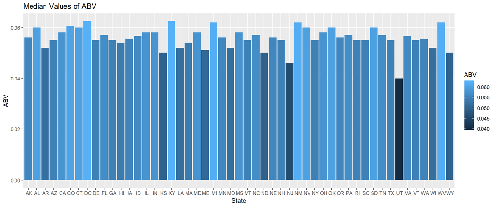

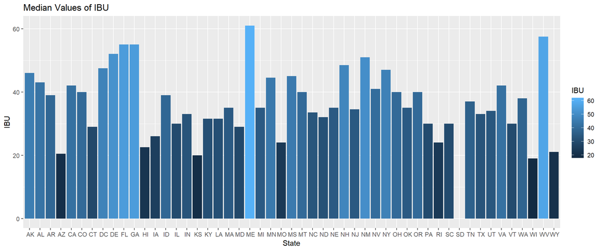

## From this data, we are able to determine which states have the most bitter and most alcohol by volume beers. Colorado has the Lee Hill Series Vol 5 - Belgian Sytle Quadrupel Ale, which contains 0.128 alcohol by volume, and Oregon has the most bitter beer, Bitter Bitch Imperial IPA.

Maximum ABV and IBU

|  | Brew_ID | Beer_name | Beer_ID | ABV | IBU | Style | Ounces | Name | City | State |
| --- | --- | --- | --- | --- | --- | --- | --- | --- | --- | --- |
| 375 | 52 | Lee Hill Series Vol. 5 - Belgian Style Quadrupel Ale | 2565 | 0.128 | NA | Quadrupel (Quad) | 19.2 | Upslope Brewing Company | Boulder | CO |
| 1857 | 375 | Bitter Bitch Imperial IPA | 980 | 0.082 | 138 | American Double / Imperial IPA | 12.0 | Astoria Brewing Company | Astoria | OR |

## Summary statistics for the ABV variable.

```
##    Min. 1st Qu.  Median    Mean 3rd Qu.    Max.    NA's
## 0.00100 0.05000 0.05600 0.05977 0.06700 0.12800      62
```

## From this data, we were able to determine that there is a relationship between bitterness and alcohol by volume. We cannot say wether one factor is caused or causes the other, but where there is a high ABV, there is a high probablity that it will be a bitter beer.

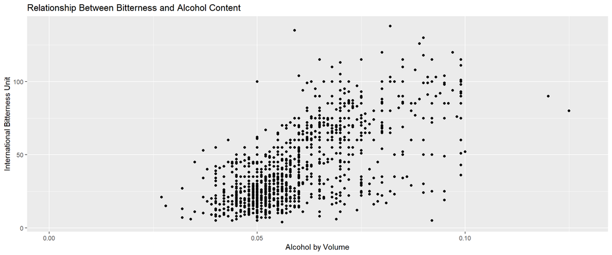

github link for source code and PPT: https://github.com/leonhuang-usa/cs1.git